# Reproducible Research: Peer Assessment 1

Bilal Hassan Nizami

## Phase 1: Loading and preprocessing the data

```r
# 1. Load the data
if(!file.exists("activity.csv")){
    unzip("activity.zip")
}
activity <- read.csv("activity.csv")

# 2. Process/transform the data
activity$date <- as.Date(activity$date, format = "%Y-%m-%d")

# Check the data
head(activity)
```

```
##   steps       date interval
## 1    NA 2012-10-01        0
## 2    NA 2012-10-01        5
## 3    NA 2012-10-01       10
## 4    NA 2012-10-01       15
## 5    NA 2012-10-01       20
## 6    NA 2012-10-01       25
```

## Phase 2: Analysis of Daily Steps and Activity Patterns

**1. Mean total number of steps taken per day**

For this part, the instructions say we can ignore the missing values (NA). We will aggregate the data by date.

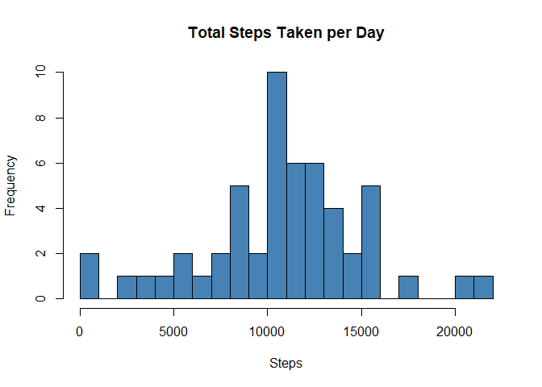

```r
## Calculate the total number of steps taken per day
total_steps_per_day <- aggregate(steps ~ date, data = activity, sum, na.rm = TRUE)

## Make a histogram of the total number of steps taken each day
hist(total_steps_per_day$steps,
     main = "Total Steps Taken per Day",
     xlab = "Steps",
     col = "steelblue",
     breaks = 20)
```

```r
## Calculate and report the mean and median
mean_steps <- mean(total_steps_per_day$steps)
median_steps <- median(total_steps_per_day$steps)
```

[output not shown]

**2. The average daily activity pattern**

Now we look at how active the individual is throughout the day by averaging each 5-minute interval across all days.

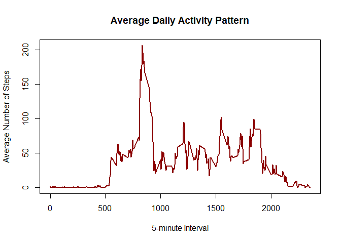

```r
## Calculate average steps per interval across all days
avg_steps_per_interval <- aggregate(steps ~ interval, data = activity, mean, na.rm = TRUE)

## Make a time series plot
plot(avg_steps_per_interval$interval, avg_steps_per_interval$steps,
     type = "l",
     col = "darkred",
     lwd = 2,
     main = "Average Daily Activity Pattern",
     xlab = "5-minute Interval",
     ylab = "Average Number of Steps")
```

```r
## Find the interval with the maximum number of steps
max_interval <- avg_steps_per_interval[which.max(avg_steps_per_interval$steps), ]
```

## Phase 3: Imputing Missing Values

First, we find out exactly how many rows are missing step data.

```r
# Calculate total number of missing values
total_nas <- sum(is.na(activity$steps))
```

**2. Strategy for imputing missing data**

A simple but effective strategy is to replace each $NA$ with the mean for that specific 5-minute interval. We already calculated these means in Phase 2 (avg_steps_per_interval).

**The impact of imputing the data is that the mean remains the same as the original estimate (since we used interval means), while the median has shifted slightly to match the mean. This suggests that imputing missing values with the mean for that interval helps maintain the central tendency while increasing the overall frequency of the total daily steps.**

**3. Create a new dataset with filled-in missing values**

We will loop through the data (or use a join/merge) to replace $NA$s.

```r
# Create a new dataset by merging the original data with the interval means
imputed_data <- activity

for (i in 1:nrow(imputed_data)) {
    if (is.na(imputed_data$steps[i])) {
        # Find the index where the intervals match
        interval_value <- imputed_data$interval[i]
        steps_value <- avg_steps_per_interval[avg_steps_per_interval$interval == interval_value, ]$steps
        # Replace NA with the average steps for that interval
        imputed_data$steps[i] <- steps_value
    }
}
```

**4. Histogram and Impact Analysis**

Now we recreate the histogram and recalculate the mean and median to see the impact.

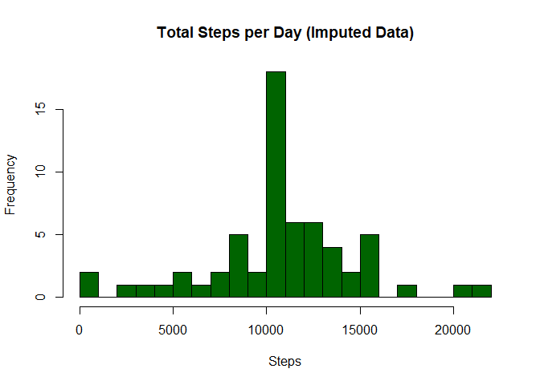

```r
# Calculate total steps per day with imputed data
total_steps_imputed <- aggregate(steps ~ date, data = imputed_data, sum)

# Make a histogram
hist(total_steps_imputed$steps,
     main = "Total Steps per Day (Imputed Data)",
     xlab = "Steps",
     col = "darkgreen",
     breaks = 20)
```

```r
# Calculate new mean and median
mean_imputed <- mean(total_steps_imputed$steps)
median_imputed <- median(total_steps_imputed$steps)
```

## Key Observations for the Report:

**Mean:** Because we used the interval means to fill the gaps, the Mean will likely stay exactly the same ($10,766$).

**Median:** The Median will usually shift slightly and often becomes equal to the Mean.

**Impact:** Imputing the data increases the total daily number of steps for the days that were previously all $NA$, making the center of our histogram taller (higher frequency).

## Phase 4: Weekdays vs. Weekends Patterns

**1. Create a new factor variable**

We need to tell R which dates are “Weekdays” and which are “Weekends.” We use the weekdays() function for this.

```r
# Create a helper function to categorize the date
day_type <- function(date) {
    day <- weekdays(date)
    if (day %in% c("Saturday", "Sunday")) {
        return("weekend")
    } else {
        return("weekday")
    }
}

# Apply the function to the imputed dataset
imputed_data$day_type <- as.factor(sapply(imputed_data$date, day_type))
```

**2. Create the Panel Plot**

We need to compare the average steps per interval for both categories. The lattice or ggplot2 libraries are perfect for “panel” (faceted) plots.

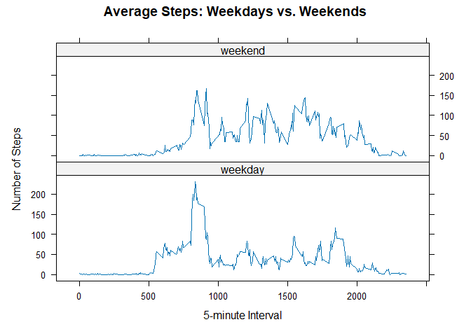

```r
# Calculate average steps by interval and day_type
avg_steps_by_daytype <- aggregate(steps ~ interval + day_type, data = imputed_data, mean)

# Load library for panel plotting
library(lattice)

# Create the panel plot
xyplot(steps ~ interval | day_type,
       data = avg_steps_by_daytype,
       type = "l",
       layout = c(1, 2),
       main = "Average Steps: Weekdays vs. Weekends",
       xlab = "5-minute Interval",
       ylab = "Number of Steps")
```